# 36-315 Homework 11, Fall 2021

# Problem 2: Processing Text Data from Reddit (20 points)

In this homework we will work with text data. `R` packages for text data often produce many messages and warnings that create messy HTML files when you Knit. To suppress these warnings, I added some `knitr` code above this paragraph in the .Rmd file such that messages and warnings aren’t printed out in any of the `R` code you submit for this homework (you’ll have to look at the .Rmd file to see what I mean). **When making your HTML files for the final project, you should suppress warnings and messages in this way - otherwise, you’ll have a very messy HTML file that’s meant for the public!**

In ongoing research, I’ve been studying gender disparities in online forums - e.g., do men, women, and non-binary people communicate differently online? And more importantly, are they treated differently? My collaborators and I have been focusing on reddit.com. For those not familiar with reddit.com (hereafter called Reddit), I will give a brief description here. Reddit is a website where users anonymously submit posts – questions, jokes, recipes, memes, gifs, and many other things – and other users reply with “upvotes”, “downvotes”, and comments. Within Reddit, there are many “subreddits,” which are basically subforums dedicated to particular topics.

Gender disparities are difficult to assess on Reddit because it is anonymous, and thus we usually do not know users’gender. However, on the /r/relationships subreddit – where users ask for advice about relationships (which could be romantic, platonic, professional, etc.) – it is very common for users to “declare” their gender. In this way, the /r/relationships subreddit is uniquely different from most other parts of Reddit. For example, someone may make a post with the title, “My [25F] roommate [24M] refuses to do the dishes.” In this case, the poster has “declared” that they are a 25-year-old female with a 24-year-old male roommate. My collaborators and I downloaded every text-based Reddit post ever made, focused on the /r/relationships subreddit, and algorithmically labeled each post as being made by a “male” or “female” author (or at least the ones that had a [F] or [M] label, like in the aforementioned example).

A limitation of this approach is that it excludes Reddit users who may not identify as male or female; at the time my collaborators and I weren’t aware of a common label (like [F] and [M]) for non-binary, and we focused on a binary view of gender for simplicity. For the sake of this homework we will view gender in a binary fashion, but I wanted to acknowledge the limitation of this perspective. Another limitation is that we will believe that Reddit users are telling the truth about their gender identity (e.g., someone who posts as [F] truly identifies as female). [But do we really think someone would just go on the Internet and tell lies?](https://www.youtube.com/watch?v=YWdD206eSv0)

In this homework, you will focus on a random set of 10,000 posts from this subreddit. Here’s the dataset:

```r
library(tidyverse)
data = read.csv("https://raw.githubusercontent.com/zjbranson/315Fall2021/main/redditData.csv")
```

The main variables we’ll focus on in this homework are:

- `title`: The text of the title of each post.
- `gender`: The gender of each poster. For simplicity, we are focusing on male and female posters.

The URL of each post is also available in the dataset, if you’re curious what these posts are about (however, this is not necessary for you to look at for this homework). Note that some of these posts are explicit, so read at your own discretion.

1. (10pts) If you haven’t already done so, install the `tm` library. To get you started, the following line of code recodes the `title` column into a `Corpus`, which is necessary to use the functions in the `tm` library:

```r
library(tm)
title = Corpus(VectorSource(data$title))
```

Using the `tm_map()` function, change all the titles to lowercase, remove punctuation, and remove extra white space.

```r
#change to lowercase
title <- tm_map(title, content_transformer(tolower))
# Remove punctuations
title <- tm_map(title, removePunctuation)
# Eliminate extra white spaces
title <- tm_map(title, stripWhitespace)
```

After you’ve done this, answer the following questions:

- Create a Document-Term Matrix of the titles using the `DocumentTermMatrix()` function. How many unique terms are in the resulting matrix?

```r
#make document term matrix
DocumentTermMatrix(title)
```

```
## <<DocumentTermMatrix (documents: 10000, terms: 8323)>>
## Non-/sparse entries: 122061/83107939
## Sparsity           : 100%
## Maximal term length: 26
## Weighting          : term frequency (tf)
```

*We see that there are 8323 uniqe terms.*

```r
#remove stop words, perform stemming
dtm.title = DocumentTermMatrix(title, control = list(stopwords = TRUE, stemming = TRUE))
dtm.title
```

```
## <<DocumentTermMatrix (documents: 10000, terms: 6166)>>
## Non-/sparse entries: 86032/61573968
## Sparsity           : 100%
## Maximal term length: 26
## Weighting          : term frequency (tf)
```

*After removing stop words and performing stemming, we see that there are 6166 unique terms.*

- Using the Document-Term Matrix you just made, `dtm.title`, what are the top ten most frequent words? Please display these words from most frequent to least frequent. For this task, you just need to write code that output’s the top ten words; you don’t need to make a graph.

```r
#words and their frequencies
title.words = dtm.title$dimnames$Terms
title.freqs = colSums(as.matrix(dtm.title))
sort(title.freqs, decreasing = TRUE)[1:10]
```

```
##         year       friend        month    boyfriend   girlfriend         want
##         2765         1663         1430         1405         1344         1132
## relationship         feel         dont         know
##         1075         1004          899          797
```

2. (10pts) Let’s look at word usage for males and females. First, create two subsets of the data: one that contains only “male” posts and one that contains “female” posts. Then, for each subset, convert the titles to a `Corpus` object, just like I did in Part A. Call these `Corpus` objects `title.male` and `title.female`, respectively.

```r
#male and female subsets
data.male = subset(data, gender == "M")
data.female = subset(data, gender == "F")
#redefine as Corpus
title.male = Corpus(VectorSource(data.male$title))
title.female = Corpus(VectorSource(data.female$title))
```

After you’ve done that, repeat the preprocessing from Part A (change all the titles to lowercase, remove punctuation, and remove extra white space) for `title.male` and `title.female`. After preprocessing, create a Document-Term Matrix (removing stopwords and performing stemming) for `title.male` and `title.female`.

```r
#change to lowercase
title.male <- tm_map(title.male, content_transformer(tolower))
title.female <- tm_map(title.female, content_transformer(tolower))
# Remove punctuations
title.male <- tm_map(title.male, removePunctuation)
title.female <- tm_map(title.female, removePunctuation)
# Eliminate extra white spaces
title.male <- tm_map(title.male, stripWhitespace)
title.female <- tm_map(title.female, stripWhitespace)

#document-term matrices
dtm.title.male = DocumentTermMatrix(title.male, control = list(stopwords = TRUE, stemming = TRUE))
dtm.title.female = DocumentTermMatrix(title.female, control = list(stopwords = TRUE, stemming = TRUE))
```

After you’ve done that, answer the folowing questions:

- How many documents and unique terms are in the male posts subset? How about the female posts subset?

```r
dtm.title.male
```

```
## <<DocumentTermMatrix (documents: 5153, terms: 4172)>>
## Non-/sparse entries: 42993/21455323
## Sparsity           : 100%
## Maximal term length: 26
## Weighting          : term frequency (tf)
```

```r
dtm.title.female
```

```
## <<DocumentTermMatrix (documents: 4847, terms: 4234)>>
## Non-/sparse entries: 43039/20479159
## Sparsity           : 100%
## Maximal term length: 23
## Weighting          : term frequency (tf)
```

*From the above, we see that, among the male titles, there are 5153 documents and 4172 unique terms. Meanwhile, among the female titles, we see that there are 4847 documents and 4234 unique terms.*

- What are the top ten most frequent words for males? What about for females? Please display these words from most frequent to least frequent. Then, compare and contrast these two top-ten lists of words.

```r
#words and their frequencies
title.male.words = dtm.title.male$dimnames$Terms
title.male.freqs = colSums(as.matrix(dtm.title.male))

title.female.words = dtm.title.female$dimnames$Terms
title.female.freqs = colSums(as.matrix(dtm.title.female))

#top ten words for males
sort(title.male.freqs, decreasing = TRUE)[1:10]
```

```
##         year   girlfriend        month       friend         want relationship
##         1527         1239          871          837          600          596
##         feel         dont         know         date
##          516          445          414          385
```

```r
#top ten words for females
sort(title.female.freqs, decreasing = TRUE)[1:10]
```

```
##    boyfriend         year       friend        month         want         feel
##         1290         1238          826          559          532          488
## relationship         dont          22f          21f
##          479          454          415          389
```

*The most clear difference between the two sets of words above is that males tend to use the word “girlfriend” frequently while females tend to use the word “boyfriend” frequently (this is unsurprising if we assume that most people in this subset of data are heterosexual). Meanwhile, both males and females use the word “friend” frequently, as well as time-related words like “year” and “month” and intimacy-related words like “want”, “relationship”, and “feel.” Another interesting difference between the two sets of words is that females frequently use “22f” and “21f”, which is a tag for “22-year-old female” and “21-year-old female,” respectively. This may suggest that the age demographic among female posters is more homogeneous than male posters.*

# Problem 3: Word Clouds (40 points)

1. (8pts) In Problem 2A, you should have made a Document-Term matrix called `dtm.title`, where you removed stop words and performed stemming after processing the data using `tm_map()`. In this problem, you’ll use `dtm.title` to make a word cloud of frequently used words in Reddit post titles.

After loading the `wordcloud` library, use `dtm.title` to make a word cloud of the Reddit titles using the `wordcloud()` function. When using this function, specify the following arguments:

- `words`
- `freq`
- `max.words`
- `random.order`
- `colors`
- `rot.per`

For the above arguments, choose specifications that you think make the word cloud look good (i.e., visually pleasing and interpretable).

*In Problem 2A, we already used `dtm.title` to define `title.words` and `title.freqs` (the unique words and their frequencies among the Reddit titles), and that’s all we need to make the word cloud below:*

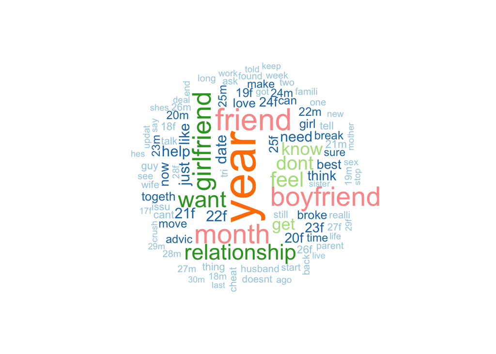

```r
library(wordcloud)
wordcloud(words = title.words, freq = title.freqs,
    random.order = FALSE, max.words = 100, colors=brewer.pal(8, "Paired"), rot.per = 0.2)
```

After you’ve made your word cloud, in 1-2 sentences, make some observations about the word cloud (there aren’t necessarily specific “right” answers here - just mention what stands out to you).

*From the word cloud above, we can see that time words like “year” and “month” are very common, probably denoting the amount of time that people have been in relationships. The words “boyfriend” and “girlfriend” are also extremely common, which is unsurprising given that these posts are about relationships. We also see a lot of age/gender tags (e.g., 20f, 20m, etc.) This is also unsurprising since it is common practice among /r/relationships to declare your age and gender; however, from this we can see that most people posting to /r/relationships are in their early 20s.*

**Hints**: In Problem 2A, you should have already computed `words` and `freq` (the first two arguments). Details about the next three arguments are discussed in the R demo. Finally, we haven’t talked about the last argument (`rot.per`), so look at the help documentation (`help(wordcloud)`) to understand what this argument does.

2. (16pts) In Problem 2B, you should have made a Document-Term matrix for male posts specifically and a Document-Term matrix for female posts specifically, where you removed stop words and performed stemming after processing the data using `tm_map()`. Using those Document-Term matrices, make a word cloud for male posts and a word cloud for female posts. Similar to Part A, choose specifications for the arguments of `wordcloud()` that make these word clouds visually pleasing to you. Arrange these word clouds in a 1x2 grid using `par(mfrow=c(1,2))`. When you Knit, you may find that the world clouds aren’t fully displayed; if this is the case for you, set `fig.width = 10` within “{r}” when writing your code for the wordcloud (i.e., write `{r, fig.width = 10}` instead).

*In Problem 2B, we defined `title.male.words` and `title.male.freqs` (the unique words and their frequencies among the Reddit titles for males), as well as the analogous `title.female.words` and `title.female.freqs`. That’s all we need to make the word cloud below:*

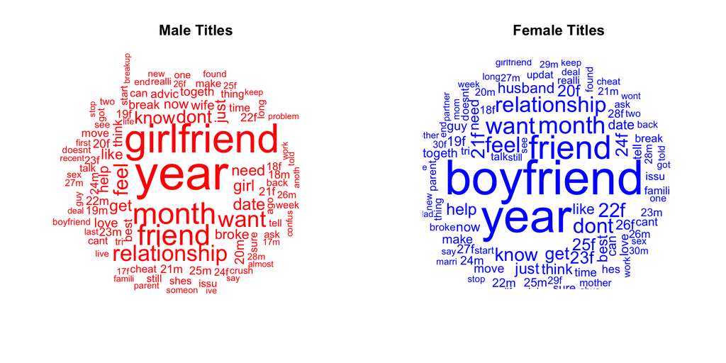

```r
par(mfrow=c(1,2))
wordcloud(words = title.male.words, freq = title.male.freqs,
    random.order = FALSE, max.words = 100, colors="red", rot.per = 0.2)
title(main = "Male Titles")
wordcloud(words = title.female.words, freq = title.female.freqs,
    random.order = FALSE, max.words = 100, colors="blue", rot.per = 0.2)
title(main = "Female Titles")
```

After you’ve made your word clouds, compare and contrast the word clouds in 1-2 sentences.

*The observations to be made here are pretty similar to the observations we made in Problem 2B. For example, again we see that the most clear difference between the two sets of words above is that males tend to use the word “girlfriend” frequently while females tend to use the word “boyfriend” frequently (this is unsurprising if we assume that most people in this subset of data are heterosexual). Meanwhile, both males and females use time-related words like “year” and “month” and intimacy-related words like “want”, “relationship”, and “feel.”*

3. (16pts) Now let’s make some comparison word clouds that compare word usage for male and female posts. To get you started, the following code combines `title.male` and `title.female` into one `Corpus`, converts the Corpus to a plain text document, and then computes a Term-Document Matrix. **Before running this code, be sure that you have already properly defined `title.male` and `title.female` in Problem 2B.** (I considered asking you to write this code yourself, but I thought, “It’s the last homework—why not give these students a break?”)

```r
#put the male and female titles into one corpus
titleMaleFemale = tm:::c.VCorpus(title.male, title.female)
titleMaleFemale = tm_map(titleMaleFemale, PlainTextDocument)

#remove stop words, perform stemming
titleMaleFemale = tm_map(titleMaleFemale, removeWords, stopwords("english"))
titleMaleFemale = tm_map(titleMaleFemale, stemDocument)

#term-document matrix
tdm_maleFemale <- TermDocumentMatrix(titleMaleFemale)

#convert to a matrix class
tdm_maleFemale = as.matrix(tdm_maleFemale)
```

As of now, the matrix `tdm_maleFemale` should have 10000 columns (for each of the 10000 titles) and number of rows equal to the number of unique words (this should be very close to the number you wrote down for Problem 2A - it’s okay if it’s not exact).

Now we will create two different comparison word clouds, and compare/contrast them. For this part, please complete the following **three tasks**:

- First, make a comparison word cloud using `tdm_maleFemale`. To do this, you’ll have to create a new matrix with just two columns: The first column sums the word counts across all male documents, and the other column does the same for female documents, where the rows correspond to the individual words in the Term-Document matrix. Call this matrix `tdm_maleFemale_sum`, and run `colnames(tdm_maleFemale_sum) = c("Male" ,"Female")` to change the column names of this matrix. Then, use `tdm_maleFemale_sum` and `comparison.cloud()` to create a comparison world cloud for male and female posts. Note that we went through a very similar process in lecture and the R demo. Similar to Part A, choose specifications for the arguments of `comparison.cloud()` that make these word clouds visually pleasing to you.

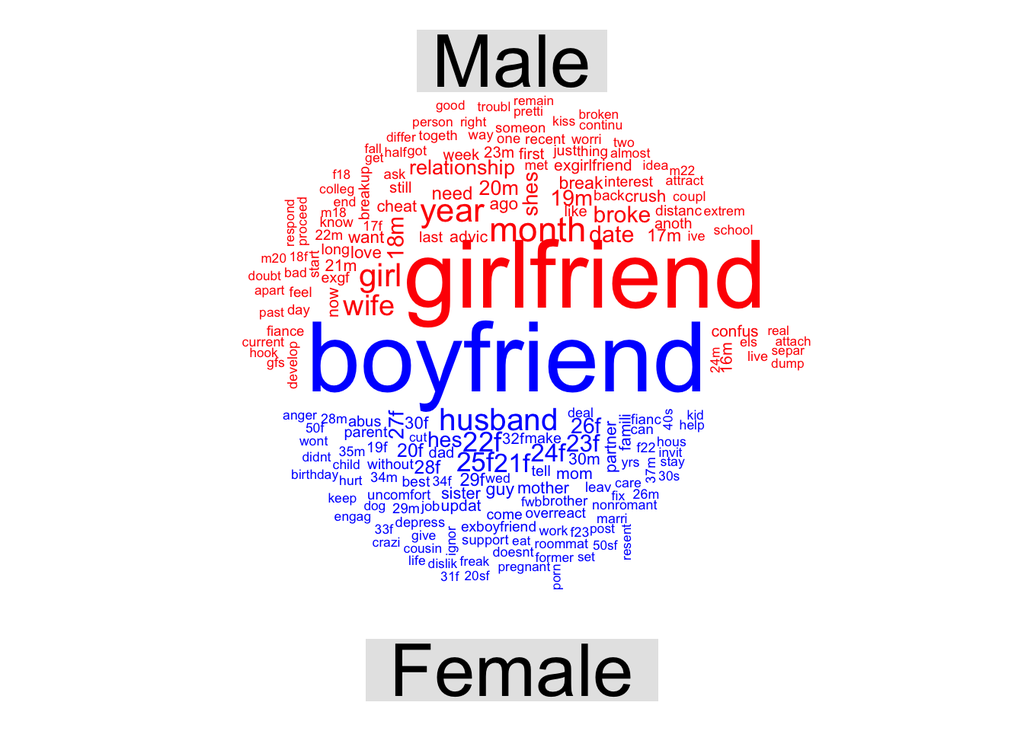

```r
#aggregate the word counts across males and females
tdm_male_sum = rowSums(tdm_maleFemale[,1:5153])
tdm_female_sum = rowSums(tdm_maleFemale[,5154:10000])
#combine these two aggregations
tdm_maleFemale_sum = cbind(tdm_male_sum, tdm_female_sum)
#rename the columns according to the group
colnames(tdm_maleFemale_sum) = c("Male", "Female")
#comparison word cloud
comparison.cloud(tdm_maleFemale_sum, random.order = FALSE,
                 colors = c("red", "blue"), max.words = 200)
```

- The comparison word cloud you made above was created using the raw word counts contained in `tdm_maleFemale`. As we discussed in class, it can be useful to instead use TF-IDF weights within a Term-Document matrix when making comparison word clouds. For this task, again make a comparison word cloud, but where you use TF-IDF weights instead when making the Term-Document matrix. For this task, you should be able to copy-and-paste your code from the previous task, but then alter it slightly such that it incorporates TF-IDF weights instead.

*For this part, the only change we had to make was to incorporate TF-IDF weighting when defining the Term-Document matrix:*

```r
#term-document matrix
tdm_maleFemale_tfidf <- TermDocumentMatrix(titleMaleFemale,
                                           control = list(weighting = weightTfIdf))

#convert to a matrix class
tdm_maleFemale_tfidf = as.matrix(tdm_maleFemale_tfidf)
```

*The remaining code is exactly the same as that for the previous task, except now we refer to the new Term-Document matrix `tdm_maleFemale_tfidf`.*

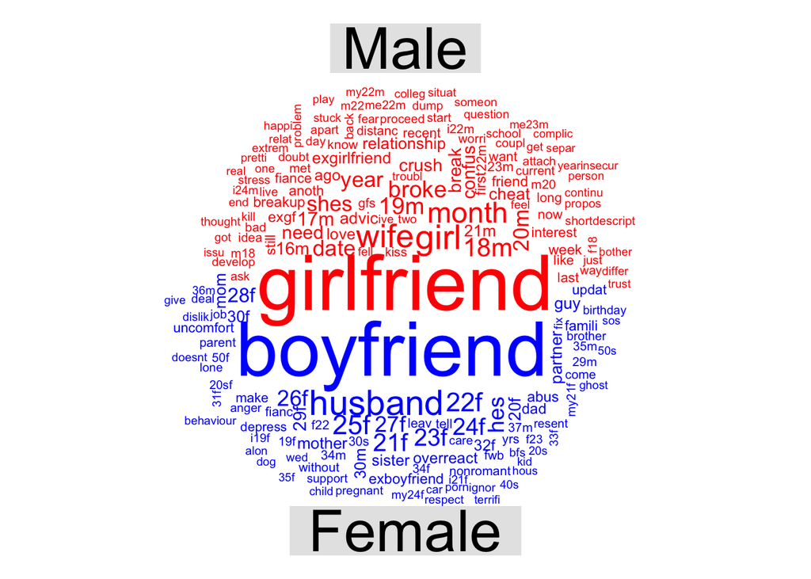

```r
#aggregate the TF-IDF weights across males and females
tdm_male_sum_tfidf = rowSums(tdm_maleFemale_tfidf[,1:5153])
tdm_female_sum_tfidf = rowSums(tdm_maleFemale_tfidf[,5154:10000])
#combine these two aggregations
tdm_maleFemale_sum_tfidf = cbind(tdm_male_sum_tfidf, tdm_female_sum_tfidf)
#rename the columns according to the group
colnames(tdm_maleFemale_sum_tfidf) = c("Male", "Female")
#comparison word cloud
comparison.cloud(tdm_maleFemale_sum_tfidf, random.order = FALSE,
                 colors = c("red", "blue"), max.words = 200)
```

- After you’ve made your word clouds, interpret them in 1-2 sentences. Then, compare and contrast the two word clouds in another 1-2 sentences.

*In both comparison word clouds, we can even more distinctly see heterosexual trends (as we’ve noted earlier in this homework): Males tend to use words like “girl,” “girlfriend,” and “wife,” while females tend to use words like “boyfriend” and “husband.” This is what’s most common about the two comparison word clouds: These gendered words dominate the word clouds, especially “boyfriend” and “girlfriend.” Meanwhile, what differs between the two comparison word clouds is that the TF-IDF comparison word cloud tends to slightly upweigh more small-to-medium sized words. For example, by looking at the TF-IDF comparison word cloud specifically, we can more easily see that male posters tend to be younger (about 17 to 21 years old) while female posters tend to be older (about 21 to 25 years old). Interestingly, relationship-related words like “break,” “broke,” “crush,” and “cheat” tend to be amongst male titles, while more family-oriented words like “famili” (due to stemming), “mother,” “dad,” “child,” and “partner” tend to be amongst female titles. We can also see these trends in the original comparison word cloud without TF-IDF weights, but it is more difficult, because most words (besides “girlfriend” and “boyfriend”) are very small in that comparison word cloud.*

# Problem 4: Sentiment Analysis (25 points)

Now we will examine what types of “positive” and “negative” words men and women use on Reddit.

1. (10pts) In Problem 2B, you should have defined the unique words used by men and women and the frequencies of those words. Create a data.frame called `maleTitle.df` with the unique words (for males) in one column and their frequencies in another column. Also create an analogous data.frame called `femaleTitle.df` for females.

```r
maleTitle.df = data.frame(word = title.male.words, count = title.male.freqs)
femaleTitle.df = data.frame(word = title.female.words, count = title.female.freqs)
```

After doing this, install the `tidytext` R package (if you haven’t already done so), and define a data.frame that contains (1) the unique words (for males) in one column, their frequencies in another column, and (3) whether the word is “positive” or “negative” based on the Bing dictionary. Similarly define a data.frame for females. The datasets you define below should have much fewer rows than `maleTitle.df` or `femaleTitle.df`, because only a subset of the words in these datasets will be in the Bing dictionary.

```r
library(tidytext)
library(tidyverse)
#label each word with a positive or negative sentiment
#(if it has one)
maleSentiments <- maleTitle.df %>%
   inner_join(get_sentiments("bing"))
femaleSentiments <- femaleTitle.df %>%
   inner_join(get_sentiments("bing"))
```

Using these data frames, answer the following questions:

- What is the total frequency of positive and negative words for males? What is the total frequency of positive and negative words for females?

```r
#total positive and negative words for males
maleSentiments %>% group_by(sentiment) %>% summarize(total = sum(count))
```

```
## # A tibble: 2 × 2
##   sentiment total
##   <chr>     <dbl>
## 1 negative   3179
## 2 positive   1536
```

```r
#total positive and negative words for females
femaleSentiments %>% group_by(sentiment) %>% summarize(total = sum(count))
```

```
## # A tibble: 2 × 2
##   sentiment total
##   <chr>     <dbl>
## 1 negative   2877
## 2 positive   1482
```

*From the above, we can see that males have used 1536 positive words and 3179 negative words in their titles. We can also see that females have used 1482 positive words and 2877 negative words.*

- Is the proportion of positive words (compared to negative words) significantly different between males and females? Answer this question using a statistical test.

*To test if the proportion of positive words is significantly different between males and females, we use the `prop.test()` function (where `x` is the total number of positive words, and `n` is the total number of positive or negative words).*

```r
prop.test(x = c(1536, 1482),
          n = c(1536 + 3179, 1482 + 2877))
```

```
##
##  2-sample test for equality of proportions with continuity correction
##
## data:  c(1536, 1482) out of c(1536 + 3179, 1482 + 2877)
## X-squared = 1.999, df = 1, p-value = 0.1574
## alternative hypothesis: two.sided
## 95 percent confidence interval:
##  -0.033847019  0.005412194
## sample estimates:
##    prop 1    prop 2
## 0.3257688 0.3399862
```

*From the above $p$-value (0.1574), we fail to reject the null hypothesis at the $\alpha = 0.05$ level. Thus, we do not find evidence that the proportion of positive words is different between males and females.*

**Hint**: For the second bullet point, I could be mean and say, “You should have learned this in a previous stats class, so why should I give you any hints??” But the semester is almost over and we’re all tired so here’s a hint. Use the `prop.test()` function. This function takes two arguments: `x` and `n`. `x` is the vector of “number of successes”, and `n` is the vector of “number of trials”. Thus, if `x` and `n` are vectors of length 2 (one number for males, one number for females), then `prop.test()` will test if the proportion of successes is different between the two groups. So, think carefully what `x` and `n` should be for this problem; in particular, imagine going through each word and labeling it as either positive (a “success”) or negative (not a “success”).

2. (15pts) Regardless of whether or not men and women have significantly different proportions of positive words, they may be using different kinds of positive and negative words, so we are going to assess that here.

Make (1) a word cloud of the *positive* words that males use, and (2) a word cloud of the *positive* words that females use. Put these two word clouds side-by-side using `par(mfrow=c(1,2))`. Repeat this for `negative` words. Again, you may have to write `{r, fig.width = 10}` so that your word clouds fully display when you Knit your file. (Thus, your submission should have four word clouds, corresponding to the different positive/negative and male/female combinations.)

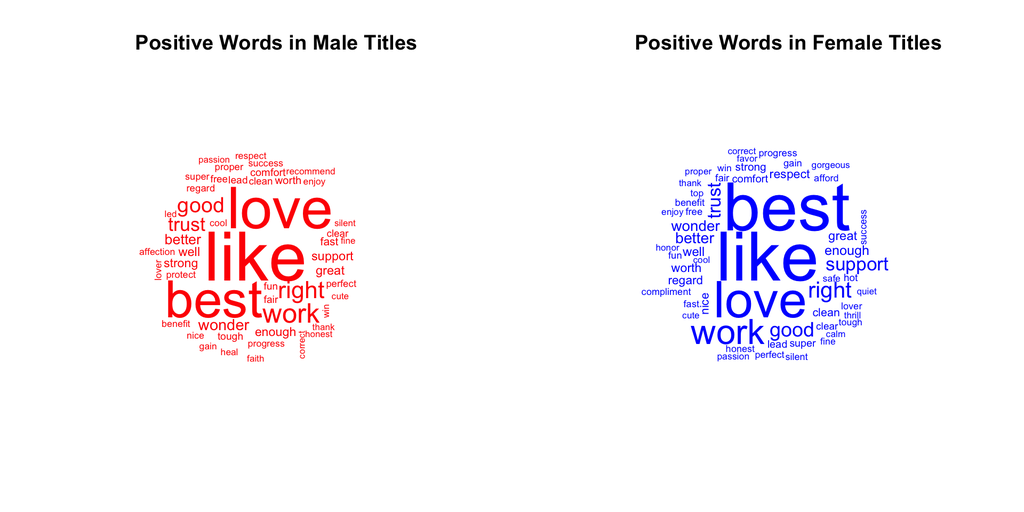

```r
par(mfrow = c(1,2))
#word clouds for positive words for males
maleSentiments %>%
  filter(sentiment == "positive") %>%
  with(wordcloud(words = word, freq = count,
                 random.order = FALSE, color = "red", max.words = 200))
title(main = "Positive Words in Male Titles")
#word clouds for positive words for females
femaleSentiments %>%
  filter(sentiment == "positive") %>%
  with(wordcloud(words = word, freq = count,
                 random.order = FALSE, color = "blue", max.words = 200))
title(main = "Positive Words in Female Titles")
```

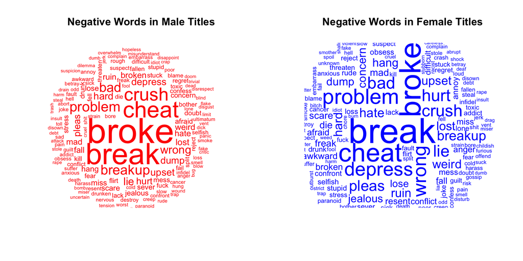

```r
par(mfrow = c(1,2))
#word clouds for negative words for males
maleSentiments %>%
  filter(sentiment == "negative") %>%
  with(wordcloud(words = word, freq = count,
                 random.order = FALSE, color = "red", max.words = 200))
title(main = "Negative Words in Male Titles")
#word clouds for negative words for males
femaleSentiments %>%
  filter(sentiment == "negative") %>%
  with(wordcloud(words = word, freq = count,
                 random.order = FALSE, color = "blue", max.words = 200))
title(main = "Negative Words in Female Titles")
```

From these plots, do you think males and females are using the same kinds of positive and negative words? Explain in 1-2 sentences.

*Overall it seems like males and females are using similar positive words (love, like, best, and work are all very common). This also seems to be the case for negative words (break, broke, cheat, crush, and problem are all very common). One thing to note is that there seems to be a more uniform distribution of negative words for females (i.e., there are more large-sized words) compared to males. This may suggest that the negative topics that females post on /r/relationships is more heterogeneous than the negative topics that males post.*

**Hint**: Use the data frames you defined in Part A.

# Problem 5: Topic Modeling (5 points)

For this problem, install the `topicmodels` `R` package.

In Problem 2A, you should have defined an object called `dtm.title`. (This is the Document-Term Matrix of titles, after preprocessing, removing stop words, and performing stemming.) If you defined this object correctly, you should be able to run the code below (taken directly from the topic modeling `R` Demo). For this problem, you don’t have to do any new coding. [All](https://www.youtube.com/watch?v=G38nXrol8gA) you have to do is uncomment and run the code, and make sure you understand what the graph is plotting.

After you’ve produced the graph from the code below: Do the two topics produced by LDA seem distinct/different? If not, this may suggest that all titles in this dataset are really just about one topic. Does this make sense, given the context of this dataset? Explain your answer in 1-3 sentences.

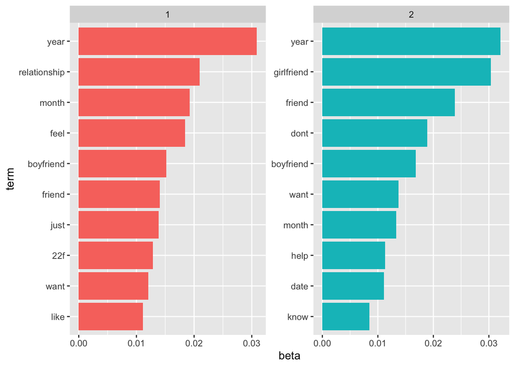

```r
library(topicmodels)
library(tidytext)
library(ggplot2)
library(tidyverse)
#run Latent Dirichlet Allocation
title_lda <- LDA(dtm.title, k = 2, control = list(seed = 1234))
#grab the word-topic probabilities
title_topics <- tidy(title_lda, matrix = "beta")
#grab the words with the top ten probabilities (betas),
#and then organize the data by topic, decreasing by beta
title_top_terms <- title_topics %>%
   group_by(topic) %>%
   top_n(10, beta) %>%
   ungroup() %>%
   arrange(topic, -beta)
#make the plot of betas for each topic
 title_top_terms %>%
   mutate(term = reorder_within(term, beta, topic)) %>%
   ggplot(aes(term, beta, fill = factor(topic))) +
   geom_col(show.legend = FALSE) +
   facet_wrap(~ topic, scales = "free") +
   coord_flip() +
   scale_x_reordered()
```